# DS-HW[1] Data Parsing and Cleansing

## Problem 1. Data Cleansing

### 1) Plot the data for each parameter.

```python
import pandas as pd
import numpy as np

import matplotlib.pyplot as plt

# csv data파일 가져오기
data = pd.read_csv("ds_hw1_dataset.csv")

# data 출력
data
```

|  | tick | ang_j3 | ang_j4 | ang_j5 | temp_j3 | temp_j4 | temp_j5 | motion_id |
| --- | --- | --- | --- | --- | --- | --- | --- | --- |
| 0 | 160049320050 | -0.554516 | -0.009215 | 1.35619 | 34.0 | 41.0 | NaN | 4 |
| 1 | 160049320051 | -0.554516 | -0.009215 | 1.35619 | 34.0 | 41.0 | 42.0 | 4 |
| 2 | 160049320053 | -0.554516 | -0.009215 | 1.35619 | 34.0 | 41.0 | 42.0 | 4 |
| 3 | 160049320054 | -0.554516 | -0.009215 | 1.35619 | 34.0 | 41.0 | 42.0 | 4 |
| 4 | 160049320056 | -0.554516 | -0.009215 | 1.35619 | 34.0 | 41.0 | 42.0 | 4 |
| ... | ... | ... | ... | ... | ... | ... | ... | ... |
| 1649291 | 160181787681 | -0.715585 | 0.428513 | 1.50056 | 45.0 | 57.0 | 53.0 | 30 |
| 1649292 | 160181787681 | -0.715585 | 0.428513 | 1.50056 | 45.0 | 57.0 | 53.0 | 30 |
| 1649293 | 160181787681 | -0.715585 | 0.428513 | 1.50056 | 45.0 | 57.0 | 53.0 | 30 |
| 1649294 | 160181787681 | -0.715585 | 0.428513 | 1.50056 | 45.0 | 57.0 | 53.0 | 30 |
| 1649295 | 160181787682 | -0.715585 | 0.428513 | 1.50056 | 45.0 | NaN | 53.0 | 30 |

1649296 rows × 8 columns

=> pd.read_csv() 함수를 이용하여 csv파일을 data로 가져왔다. data를 통해 값들을 관측한 결과, 부분마다 데이터 값이 NaN으로 되어있는 부분이 있으며, 각 파라미터마다 결측값이 존재한다는 것을 알 수 있다.

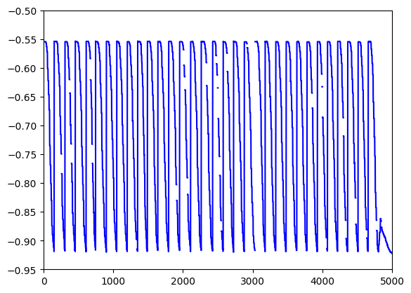

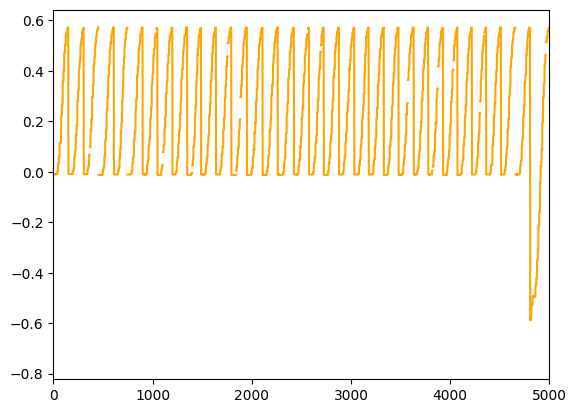

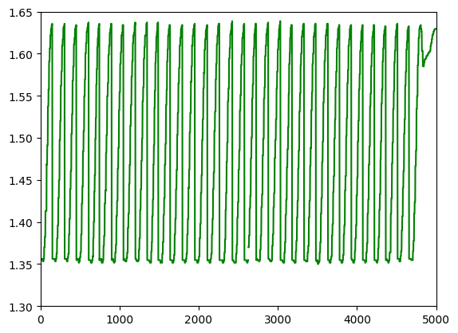

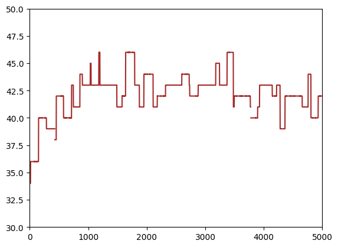

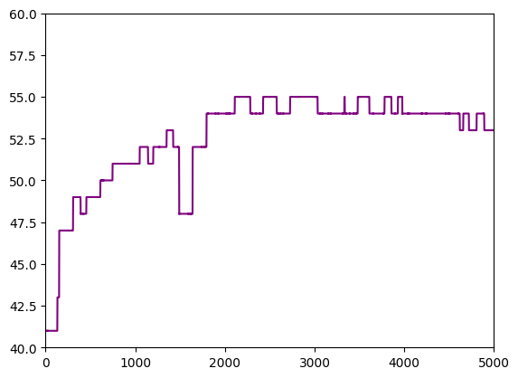

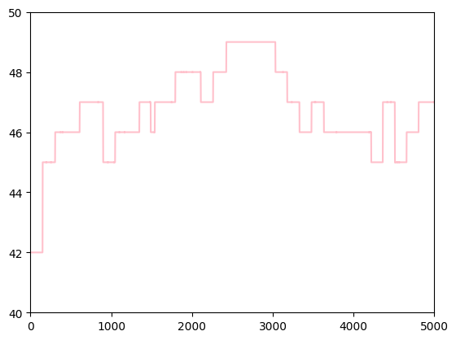

```python
# 결측값이 있는 데이터에 대한 그래프 플롯

# ang_j3 그래프 플롯
data['ang_j3'].plot(color='blue')
plt.xlim([0, 5000])
plt.ylim([-0.95, -0.50])
plt.show()

# ang_j4 그래프 플롯
data['ang_j4'].plot(color='orange')
plt.xlim([0, 5000])
plt.show()

# ang_j5 그래프 플롯
data['ang_j5'].plot(color='green')
plt.xlim([0, 5000])
plt.ylim([1.3, 1.65])
plt.show()

# temp_j3 그래프 플롯
data['temp_j3'].plot(color='brown')
plt.xlim([0, 5000])
plt.ylim([30, 50])
plt.show()

# temp_j4 그래프 플롯
data['temp_j4'].plot(color='purple')
plt.xlim([0, 5000])
plt.ylim([40, 60])
plt.show()

# temp_j5 그래프 플롯
data['temp_j5'].plot(color='pink')
plt.xlim([0, 5000])
plt.ylim([40, 50])
plt.show()
```

### 2) Find the number of missing values for each parameter.

```python
# 각 parameter마다 결측값 개수 파악
data[:5000].isnull().sum()
```

```
tick           0
ang_j3       126
ang_j4        80
ang_j5        16
temp_j3      144
temp_j4       87
temp_j5       33
motion_id      0
dtype: int64
```

### 3) Treat the missing values like this:

A) Delete data with missing values by using pandas.dropna().

```python
# dropna 함수를 통해 결측값 자동 제거 진행
data.dropna(inplace=True)

# 결측값 제거 후 개수 파악
data.isnull().sum()
```

```
tick         0
ang_j3       0
ang_j4       0
ang_j5       0
temp_j3      0
temp_j4      0
temp_j5      0
motion_id    0
dtype: int64
```

=> dropna() 함수는 데이터프레임에서 빈 곳을 찾고 해당 인덱스를 제거해주는 함수이다. 위 함수를 실행한 결과, 모든 결측값들이 제거되어 모든 파라미터에서 결측값의 개수가 0으로 관측된 것을 알 수 있다.

B) Replace the missing value with the average value within the window size (window=50) before and after the interval with missing values for each parameter.

```python
# fillna() 함수를 사용하여 설정한 윈도우 범위의 평균값으로 결측값 대체
data.fillna(data.rolling(window=31, min_periods=1, center=True).mean(), inplace=True)

# 51행까지의 데이터프레임 출력
print(data[:51])

# 결측값 제거 후 개수 파악
data.isnull().sum()
```

```
            tick    ang_j3    ang_j4   ang_j5  temp_j3  temp_j4  temp_j5  \
0   160049320050 -0.554516 -0.009215  1.35619     34.0     41.0     42.0
1   160049320051 -0.554516 -0.009215  1.35619     34.0     41.0     42.0
2   160049320053 -0.554516 -0.009215  1.35619     34.0     41.0     42.0
3   160049320054 -0.554516 -0.009215  1.35619     34.0     41.0     42.0
4   160049320056 -0.554516 -0.009215  1.35619     34.0     41.0     42.0
5   160049320058 -0.554516 -0.009215  1.35619     34.0     41.0     42.0
6   160049320059 -0.554516 -0.009215  1.35619     34.0     41.0     42.0
7   160049320061 -0.554516 -0.009215  1.35619     34.0     41.0     42.0
8   160049320063 -0.554516 -0.009215  1.35619     34.0     41.0     42.0
9   160049320065 -0.554516 -0.009215  1.35619     34.0     41.0     42.0
10  160049320066 -0.554516 -0.009215  1.35619     34.0     41.0     42.0
11  160049320068 -0.554516 -0.009215  1.35619     34.0     41.0     42.0
12  160049320069 -0.554516 -0.009215  1.35619     34.0     41.0     42.0
13  160049320071 -0.554516 -0.009215  1.35619     34.0     41.0     42.0
```

[output cut: 90 more lines]

```
tick         0
ang_j3       0
ang_j4       0
ang_j5       0
temp_j3      0
temp_j4      0
temp_j5      0
motion_id    0
dtype: int64
```

=> fillna() 함수는 데이터의 결측값을 다른 값으로 대체하는 역할을 수행한다.

rolling() 함수는 이동평균을 구하기 위한 함수로, window 사이즈를 31로 설정하고 center 를 true로 설정하여 한 가운데 인덱스를 기준으로 양쪽 15개 씩 범위에서 평균을 구한다. 그리고 min_periods를 1로 주어 최소한 하나의 유효한 데이터가 있어도 이동평균을 계산하 도록 한다. 마지막으로 inplace를 true로 주어 dataframe에서 값을 수정하도록 한다.

51행까지의 data를 출력한 결과, NaN으로 되어있던 결측값이 평균값으로 대체된 것을 확인 할 수 있다. 그리고 isnull().sum() 함수로 확인한 결과, 모든 결측값들은 제거된 것을 알 수 있다.

C) Replace the missing value with the median value within the window size (window=50) before and after the interval with missing values for each parameter.

```python
# fillna() 함수를 사용하여 설정한 윈도우 범위의 중앙값으로 결측값 대체
data.fillna(data.rolling(window=31, min_periods=1, center=True).median(), inplace=True)

# 51행까지의 데이터프레임 출력
print(data[:51])

# 결측값 제거 후 개수 파악
data.isnull().sum()
```

```
            tick    ang_j3    ang_j4   ang_j5  temp_j3  temp_j4  temp_j5  \
0   160049320050 -0.554516 -0.009215  1.35619     34.0     41.0     42.0
1   160049320051 -0.554516 -0.009215  1.35619     34.0     41.0     42.0
2   160049320053 -0.554516 -0.009215  1.35619     34.0     41.0     42.0
3   160049320054 -0.554516 -0.009215  1.35619     34.0     41.0     42.0
4   160049320056 -0.554516 -0.009215  1.35619     34.0     41.0     42.0
5   160049320058 -0.554516 -0.009215  1.35619     34.0     41.0     42.0
6   160049320059 -0.554516 -0.009215  1.35619     34.0     41.0     42.0
7   160049320061 -0.554516 -0.009215  1.35619     34.0     41.0     42.0
8   160049320063 -0.554516 -0.009215  1.35619     34.0     41.0     42.0
9   160049320065 -0.554516 -0.009215  1.35619     34.0     41.0     42.0
10  160049320066 -0.554516 -0.009215  1.35619     34.0     41.0     42.0
11  160049320068 -0.554516 -0.009215  1.35619     34.0     41.0     42.0
12  160049320069 -0.554516 -0.009215  1.35619     34.0     41.0     42.0
13  160049320071 -0.554516 -0.009215  1.35619     34.0     41.0     42.0
```

[output cut: 90 more lines]

```
tick         0
ang_j3       0
ang_j4       0
ang_j5       0
temp_j3      0
temp_j4      0
temp_j5      0
motion_id    0
dtype: int64
```

=> 마찬가지로 fillna() 함수를 이용하여 결측값 부분을 대체하였으며, 이번엔 설정한 윈도우 사이즈의 중앙값으로 값을 대체하였다. rolling()에 대한 부분함수로 median()을 사용하였 으며, 51행까지의 데이터를 출력하였을 때 결측값 부분이 대체된 것을 알 수 있다. 또한 isnull().sum() 함수로 확인한 결과, 모든 결측값들은 제거된 것을 알 수 있다.

D) Replace the missing value with the max value within the window size (window=50) before and after the interval with missing values for each parameter.

```python
# fillna() 함수를 사용하여 설정한 윈도우 범위의 최대값으로 결측값 대체
data.fillna(data.rolling(window=31, min_periods=1, center=True).max(), inplace=True)

# 51행까지의 데이터프레임 출력
print(data[:51])

# 결측값 제거 후 개수 파악
data.isnull().sum()
```

```
            tick    ang_j3    ang_j4   ang_j5  temp_j3  temp_j4  temp_j5  \
0   160049320050 -0.554516 -0.009215  1.35619     34.0     41.0     42.0
1   160049320051 -0.554516 -0.009215  1.35619     34.0     41.0     42.0
2   160049320053 -0.554516 -0.009215  1.35619     34.0     41.0     42.0
3   160049320054 -0.554516 -0.009215  1.35619     34.0     41.0     42.0
4   160049320056 -0.554516 -0.009215  1.35619     34.0     41.0     42.0
5   160049320058 -0.554516 -0.009215  1.35619     34.0     41.0     42.0
6   160049320059 -0.554516 -0.009215  1.35619     34.0     41.0     42.0
7   160049320061 -0.554516 -0.009215  1.35619     34.0     41.0     42.0
8   160049320063 -0.554516 -0.009215  1.35619     34.0     41.0     42.0
9   160049320065 -0.554516 -0.009215  1.35619     34.0     41.0     42.0
10  160049320066 -0.554516 -0.009215  1.35619     34.0     41.0     42.0
11  160049320068 -0.554516 -0.009215  1.35619     34.0     41.0     42.0
12  160049320069 -0.554516 -0.009215  1.35619     34.0     41.0     42.0
13  160049320071 -0.554516 -0.009215  1.35619     34.0     41.0     42.0
```

[output cut: 90 more lines]

```
tick         0
ang_j3       0
ang_j4       0
ang_j5       0
temp_j3      0
temp_j4      0
temp_j5      0
motion_id    0
dtype: int64
```

=> fillna() 함수를 이용하여 결측값 부분을 대체하였으며, 이번엔 설정한 윈도우사이즈의 범위에서 최대값으로 값을 대체하였다. rolling()에 대한 부분함수로 max()을 사용하였 으며, 51행까지의 데이터를 출력하였을 때 결측값 부분이 대체된 것을 알 수 있다. 그리고 isnull().sum() 함수로 확인한 결과, 모든 파라미터에서 결측값이 0개인 것으로 확인하였다.

E) Replace the missing value with the min value within the window size (window=50) before and after the interval with missing values for each parameter.

```python
# fillna() 함수를 사용하여 설정한 윈도우 범위의 최소값으로 결측값 대체
data.fillna(data.rolling(window=31, min_periods=1, center=True).min(), inplace=True)

# 51행까지의 데이터프레임 출력
print(data[:51])

# 결측값 제거 후 개수 파악
data.isnull().sum()
```

```
            tick    ang_j3    ang_j4   ang_j5  temp_j3  temp_j4  temp_j5  \
0   160049320050 -0.554516 -0.009215  1.35619     34.0     41.0     42.0
1   160049320051 -0.554516 -0.009215  1.35619     34.0     41.0     42.0
2   160049320053 -0.554516 -0.009215  1.35619     34.0     41.0     42.0
3   160049320054 -0.554516 -0.009215  1.35619     34.0     41.0     42.0
4   160049320056 -0.554516 -0.009215  1.35619     34.0     41.0     42.0
5   160049320058 -0.554516 -0.009215  1.35619     34.0     41.0     42.0
6   160049320059 -0.554516 -0.009215  1.35619     34.0     41.0     42.0
7   160049320061 -0.554516 -0.009215  1.35619     34.0     41.0     42.0
8   160049320063 -0.554516 -0.009215  1.35619     34.0     41.0     42.0
9   160049320065 -0.554516 -0.009215  1.35619     34.0     41.0     42.0
10  160049320066 -0.554516 -0.009215  1.35619     34.0     41.0     42.0
11  160049320068 -0.554516 -0.009215  1.35619     34.0     41.0     42.0
12  160049320069 -0.554516 -0.009215  1.35619     34.0     41.0     42.0
13  160049320071 -0.554516 -0.009215  1.35619     34.0     41.0     42.0
```

[output cut: 90 more lines]

```
tick         0
ang_j3       0
ang_j4       0
ang_j5       0
temp_j3      0
temp_j4      0
temp_j5      0
motion_id    0
dtype: int64
```

=> fillna() 함수를 이용하여 결측값 부분을 대체하였으며, 이번엔 설정한 윈도우사이즈의 범위에서 최소값으로 값을 대체하였다. rolling()에 대한 부분함수로 min()을 사용하였 으며, 51행까지의 데이터를 출력하였을 때 결측값 부분이 대체된 것을 알 수 있다. 그리고 isnull().sum() 함수로 확인하였을 때, 모든 결측값들이 사라진 것으로 보아 모두 최소값으로 대체되었다고 할 수 있다.

### 4) Plot the results of 3) problem and compare them.

A) Plot

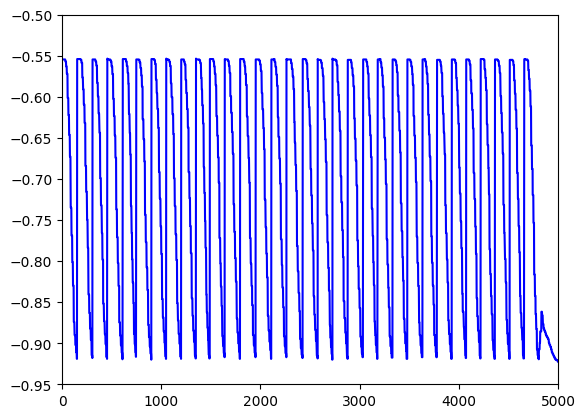

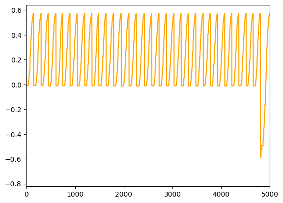

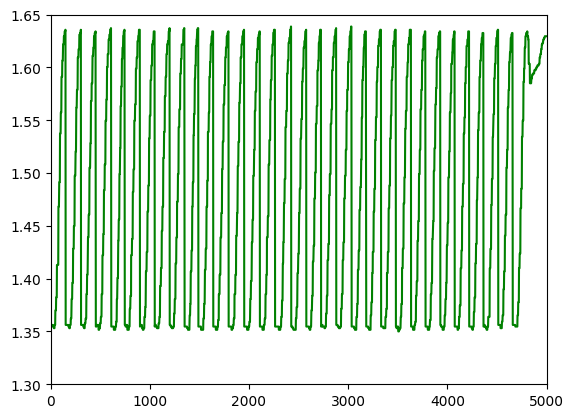

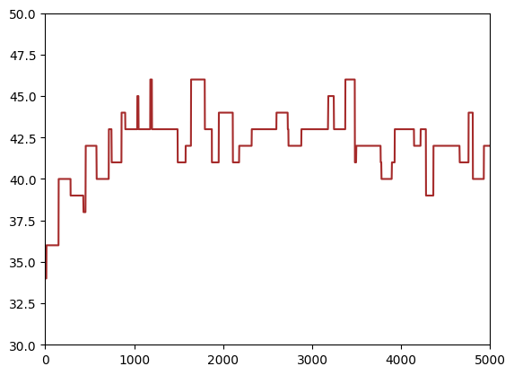

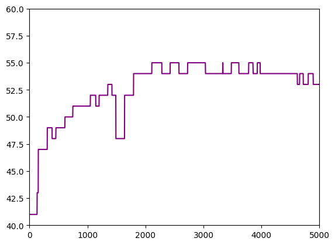

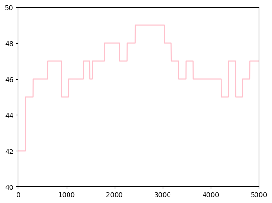

```python
# dropna() 함수로 데이터 cleansing 진행한 대한 그래프 플롯

# ang_j3 그래프 플롯
data['ang_j3'].plot(color='blue')
plt.xlim([0, 5000])
plt.ylim([-0.95, -0.50])
plt.show()

# ang_j4 그래프 플롯
data['ang_j4'].plot(color='orange')
plt.xlim([0, 5000])
plt.show()

# ang_j5 그래프 플롯
data['ang_j5'].plot(color='green')
plt.xlim([0, 5000])
plt.ylim([1.3, 1.65])
plt.show()

# temp_j3 그래프 플롯
data['temp_j3'].plot(color='brown')
plt.xlim([0, 5000])
plt.ylim([30, 50])
plt.show()

# temp_j4 그래프 플롯
data['temp_j4'].plot(color='purple')
plt.xlim([0, 5000])
plt.ylim([40, 60])
plt.show()

# temp_j5 그래프 플롯
data['temp_j5'].plot(color='pink')
plt.xlim([0, 5000])
plt.ylim([40, 50])
plt.show()
```

B) Plot

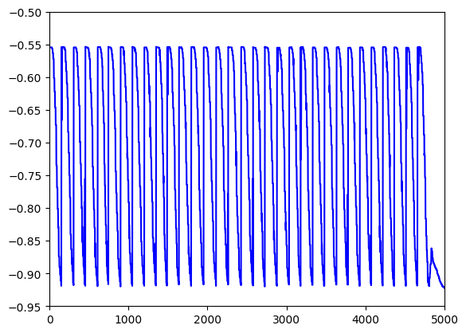

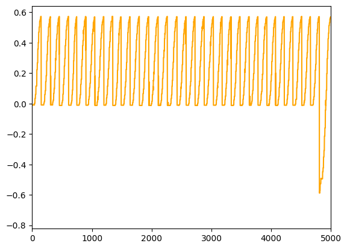

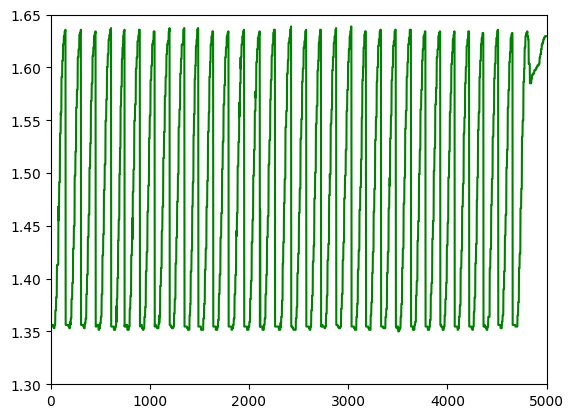

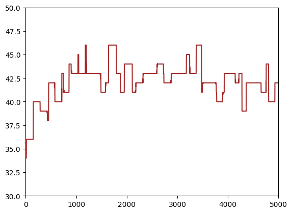

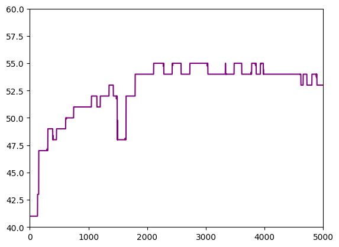

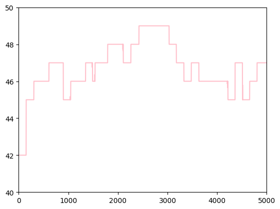

```python
# 평균값으로 데이터 cleansing 진행한 대한 그래프 플롯

# ang_j3 그래프 플롯
data['ang_j3'].plot(color='blue')
plt.xlim([0, 5000])
plt.ylim([-0.95, -0.50])
plt.show()

# ang_j4 그래프 플롯
data['ang_j4'].plot(color='orange')
plt.xlim([0, 5000])
plt.show()

# ang_j5 그래프 플롯
data['ang_j5'].plot(color='green')
plt.xlim([0, 5000])
plt.ylim([1.3, 1.65])
plt.show()

# temp_j3 그래프 플롯
data['temp_j3'].plot(color='brown')
plt.xlim([0, 5000])
plt.ylim([30, 50])
plt.show()

# temp_j4 그래프 플롯
data['temp_j4'].plot(color='purple')
plt.xlim([0, 5000])
plt.ylim([40, 60])
plt.show()

# temp_j5 그래프 플롯
data['temp_j5'].plot(color='pink')
plt.xlim([0, 5000])
plt.ylim([40, 50])
plt.show()
```

C) Plot

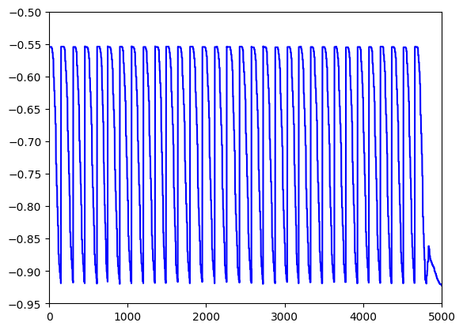

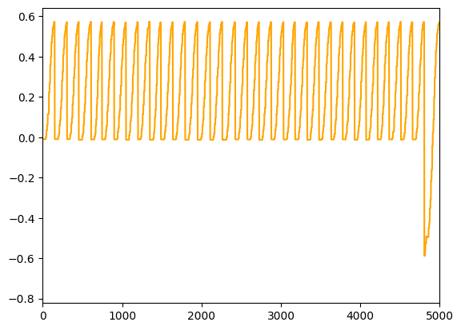

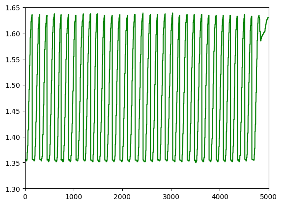

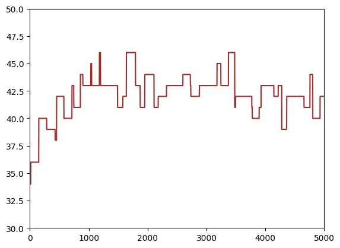

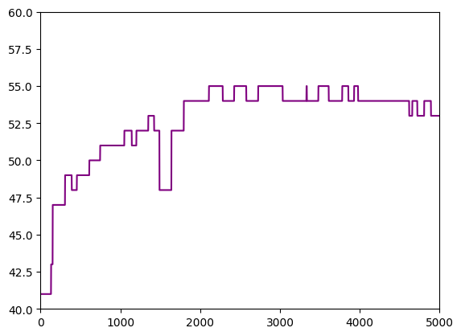

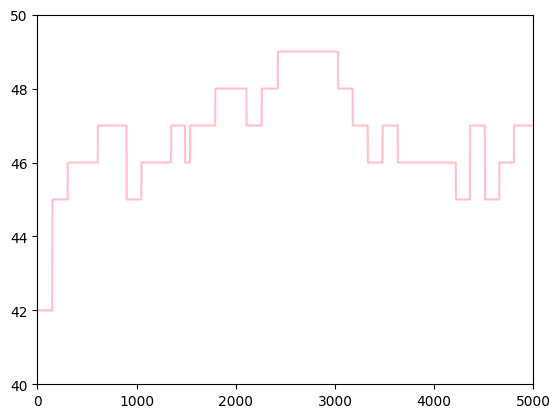

```python
# 중앙값으로 데이터 cleansing 진행한 대한 그래프 플롯

# ang_j3 그래프 플롯
data['ang_j3'].plot(color='blue')
plt.xlim([0, 5000])
plt.ylim([-0.95, -0.50])
plt.show()

# ang_j4 그래프 플롯
data['ang_j4'].plot(color='orange')
plt.xlim([0, 5000])
plt.show()

# ang_j5 그래프 플롯
data['ang_j5'].plot(color='green')
plt.xlim([0, 5000])
plt.ylim([1.3, 1.65])
plt.show()

# temp_j3 그래프 플롯
data['temp_j3'].plot(color='brown')
plt.xlim([0, 5000])
plt.ylim([30, 50])
plt.show()

# temp_j4 그래프 플롯
data['temp_j4'].plot(color='purple')
plt.xlim([0, 5000])
plt.ylim([40, 60])
plt.show()

# temp_j5 그래프 플롯
data['temp_j5'].plot(color='pink')
plt.xlim([0, 5000])
plt.ylim([40, 50])
plt.show()
```

D) Plot

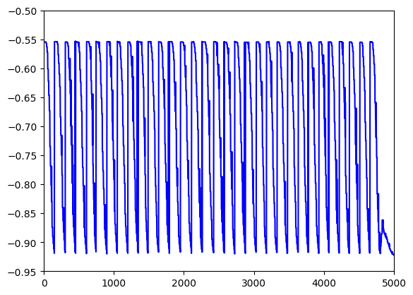

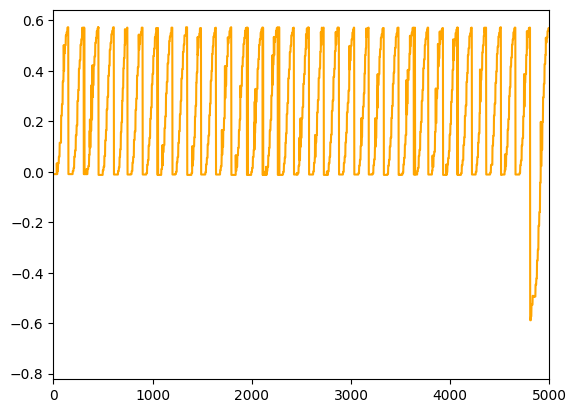

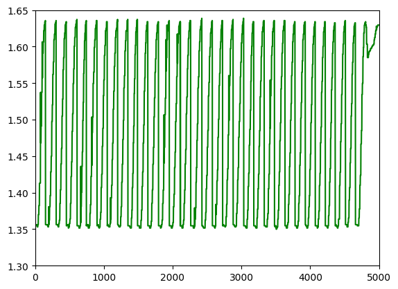

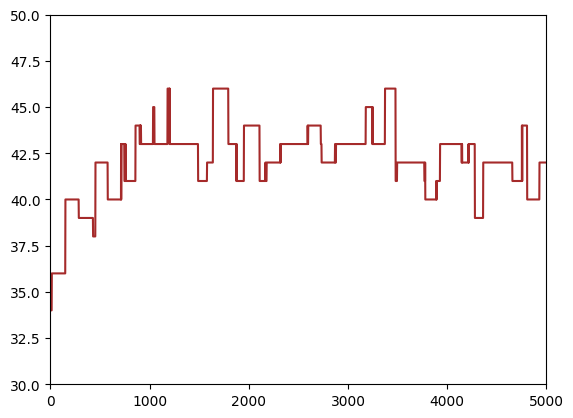

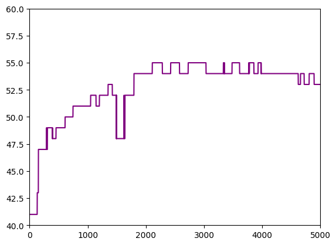

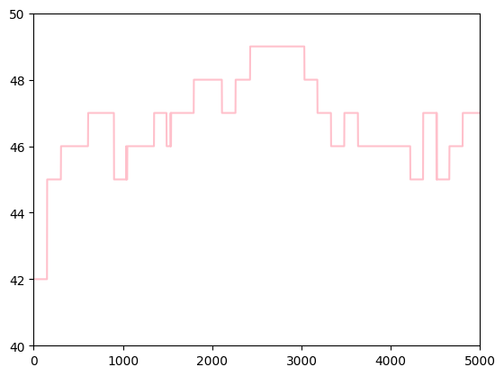

```python
# 최대값으로 데이터 cleansing 진행한 대한 그래프 플롯

# ang_j3 그래프 플롯
data['ang_j3'].plot(color='blue')
plt.xlim([0, 5000])
plt.ylim([-0.95, -0.50])
plt.show()

# ang_j4 그래프 플롯
data['ang_j4'].plot(color='orange')
plt.xlim([0, 5000])
plt.show()

# ang_j5 그래프 플롯
data['ang_j5'].plot(color='green')
plt.xlim([0, 5000])
plt.ylim([1.3, 1.65])
plt.show()

# temp_j3 그래프 플롯
data['temp_j3'].plot(color='brown')
plt.xlim([0, 5000])
plt.ylim([30, 50])
plt.show()

# temp_j4 그래프 플롯
data['temp_j4'].plot(color='purple')
plt.xlim([0, 5000])
plt.ylim([40, 60])
plt.show()

# temp_j5 그래프 플롯
data['temp_j5'].plot(color='pink')
plt.xlim([0, 5000])
plt.ylim([40, 50])
plt.show()
```